# Risk Factor Analysis

## Outcome Variable

**Outcome Variable:** ever_swasted

## Predictor Variables

**Intervention Variable:** exclfeed36

**Adjustment Set:**

unadjusted

## Stratifying Variables

The analysis was stratified on these variable(s):

- agecat
- studyid
- country

## Data Summary

| agecat | studyid | country | exclfeed36 | ever_swasted | n_cell | n |
| --- | --- | --- | --- | --- | --- | --- |
| 0-24 months (no birth wast) | CMC-V-BCS-2002 | INDIA | 1 | 0 | 9 | 9 |
| 0-24 months (no birth wast) | CMC-V-BCS-2002 | INDIA | 1 | 1 | 0 | 9 |
| 0-24 months (no birth wast) | CMC-V-BCS-2002 | INDIA | 0 | 0 | 0 | 9 |
| 0-24 months (no birth wast) | CMC-V-BCS-2002 | INDIA | 0 | 1 | 0 | 9 |
| 0-24 months (no birth wast) | EE | PAKISTAN | 1 | 0 | 4 | 9 |
| 0-24 months (no birth wast) | EE | PAKISTAN | 1 | 1 | 0 | 9 |
| 0-24 months (no birth wast) | EE | PAKISTAN | 0 | 0 | 4 | 9 |
| 0-24 months (no birth wast) | EE | PAKISTAN | 0 | 1 | 1 | 9 |
| 0-24 months (no birth wast) | GMS-Nepal | NEPAL | 1 | 0 | 330 | 524 |
| 0-24 months (no birth wast) | GMS-Nepal | NEPAL | 1 | 1 | 90 | 524 |
| 0-24 months (no birth wast) | GMS-Nepal | NEPAL | 0 | 0 | 74 | 524 |
| 0-24 months (no birth wast) | GMS-Nepal | NEPAL | 0 | 1 | 30 | 524 |
| 0-24 months (no birth wast) | IRC | INDIA | 1 | 0 | 0 | 4 |
| 0-24 months (no birth wast) | IRC | INDIA | 1 | 1 | 0 | 4 |
| 0-24 months (no birth wast) | IRC | INDIA | 0 | 0 | 3 | 4 |
| 0-24 months (no birth wast) | IRC | INDIA | 0 | 1 | 1 | 4 |
| 0-24 months (no birth wast) | JiVitA-3 | BANGLADESH | 1 | 0 | 9404 | 12568 |
| 0-24 months (no birth wast) | JiVitA-3 | BANGLADESH | 1 | 1 | 370 | 12568 |
| 0-24 months (no birth wast) | JiVitA-3 | BANGLADESH | 0 | 0 | 2698 | 12568 |
| 0-24 months (no birth wast) | JiVitA-3 | BANGLADESH | 0 | 1 | 96 | 12568 |
| 0-24 months (no birth wast) | JiVitA-4 | BANGLADESH | 1 | 0 | 3378 | 4559 |
| 0-24 months (no birth wast) | JiVitA-4 | BANGLADESH | 1 | 1 | 142 | 4559 |
| 0-24 months (no birth wast) | JiVitA-4 | BANGLADESH | 0 | 0 | 989 | 4559 |
| 0-24 months (no birth wast) | JiVitA-4 | BANGLADESH | 0 | 1 | 50 | 4559 |
| 0-24 months (no birth wast) | Keneba | GAMBIA | 1 | 0 | 544 | 1974 |
| 0-24 months (no birth wast) | Keneba | GAMBIA | 1 | 1 | 79 | 1974 |
| 0-24 months (no birth wast) | Keneba | GAMBIA | 0 | 0 | 1115 | 1974 |
| 0-24 months (no birth wast) | Keneba | GAMBIA | 0 | 1 | 236 | 1974 |
| 0-24 months (no birth wast) | LCNI-5 | MALAWI | 1 | 0 | 47 | 271 |
| 0-24 months (no birth wast) | LCNI-5 | MALAWI | 1 | 1 | 0 | 271 |

[output cut: 174 more lines]

The following strata were considered:

- agecat: 0-24 months (no birth wast), studyid: CMC-V-BCS-2002, country: INDIA
- agecat: 0-24 months (no birth wast), studyid: EE, country: PAKISTAN
- agecat: 0-24 months (no birth wast), studyid: GMS-Nepal, country: NEPAL
- agecat: 0-24 months (no birth wast), studyid: IRC, country: INDIA
- agecat: 0-24 months (no birth wast), studyid: JiVitA-3, country: BANGLADESH
- agecat: 0-24 months (no birth wast), studyid: JiVitA-4, country: BANGLADESH
- agecat: 0-24 months (no birth wast), studyid: Keneba, country: GAMBIA
- agecat: 0-24 months (no birth wast), studyid: LCNI-5, country: MALAWI
- agecat: 0-24 months (no birth wast), studyid: MAL-ED, country: BANGLADESH
- agecat: 0-24 months (no birth wast), studyid: MAL-ED, country: BRAZIL
- agecat: 0-24 months (no birth wast), studyid: MAL-ED, country: INDIA
- agecat: 0-24 months (no birth wast), studyid: MAL-ED, country: NEPAL
- agecat: 0-24 months (no birth wast), studyid: MAL-ED, country: PERU
- agecat: 0-24 months (no birth wast), studyid: MAL-ED, country: SOUTH AFRICA
- agecat: 0-24 months (no birth wast), studyid: MAL-ED, country: TANZANIA, UNITED REPUBLIC OF
- agecat: 0-24 months (no birth wast), studyid: PROVIDE, country: BANGLADESH
- agecat: 0-24 months (no birth wast), studyid: SAS-FoodSuppl, country: INDIA
- agecat: 0-6 months (no birth wast), studyid: CMC-V-BCS-2002, country: INDIA
- agecat: 0-6 months (no birth wast), studyid: EE, country: PAKISTAN
- agecat: 0-6 months (no birth wast), studyid: GMS-Nepal, country: NEPAL
- agecat: 0-6 months (no birth wast), studyid: IRC, country: INDIA
- agecat: 0-6 months (no birth wast), studyid: JiVitA-3, country: BANGLADESH
- agecat: 0-6 months (no birth wast), studyid: JiVitA-4, country: BANGLADESH
- agecat: 0-6 months (no birth wast), studyid: Keneba, country: GAMBIA
- agecat: 0-6 months (no birth wast), studyid: LCNI-5, country: MALAWI
- agecat: 0-6 months (no birth wast), studyid: MAL-ED, country: BANGLADESH
- agecat: 0-6 months (no birth wast), studyid: MAL-ED, country: BRAZIL
- agecat: 0-6 months (no birth wast), studyid: MAL-ED, country: INDIA
- agecat: 0-6 months (no birth wast), studyid: MAL-ED, country: NEPAL
- agecat: 0-6 months (no birth wast), studyid: MAL-ED, country: PERU
- agecat: 0-6 months (no birth wast), studyid: MAL-ED, country: SOUTH AFRICA
- agecat: 0-6 months (no birth wast), studyid: MAL-ED, country: TANZANIA, UNITED REPUBLIC OF
- agecat: 0-6 months (no birth wast), studyid: PROVIDE, country: BANGLADESH
- agecat: 0-6 months (no birth wast), studyid: SAS-FoodSuppl, country: INDIA
- agecat: 6-24 months, studyid: CMC-V-BCS-2002, country: INDIA
- agecat: 6-24 months, studyid: EE, country: PAKISTAN
- agecat: 6-24 months, studyid: GMS-Nepal, country: NEPAL
- agecat: 6-24 months, studyid: IRC, country: INDIA
- agecat: 6-24 months, studyid: JiVitA-3, country: BANGLADESH
- agecat: 6-24 months, studyid: JiVitA-4, country: BANGLADESH
- agecat: 6-24 months, studyid: Keneba, country: GAMBIA
- agecat: 6-24 months, studyid: LCNI-5, country: MALAWI
- agecat: 6-24 months, studyid: MAL-ED, country: BANGLADESH
- agecat: 6-24 months, studyid: MAL-ED, country: BRAZIL
- agecat: 6-24 months, studyid: MAL-ED, country: INDIA
- agecat: 6-24 months, studyid: MAL-ED, country: NEPAL
- agecat: 6-24 months, studyid: MAL-ED, country: PERU
- agecat: 6-24 months, studyid: MAL-ED, country: SOUTH AFRICA
- agecat: 6-24 months, studyid: MAL-ED, country: TANZANIA, UNITED REPUBLIC OF
- agecat: 6-24 months, studyid: PROVIDE, country: BANGLADESH
- agecat: 6-24 months, studyid: SAS-FoodSuppl, country: INDIA

### Dropped Strata

Some strata were dropped due to rare outcomes:

- agecat: 0-24 months (no birth wast), studyid: CMC-V-BCS-2002, country: INDIA
- agecat: 0-24 months (no birth wast), studyid: EE, country: PAKISTAN
- agecat: 0-24 months (no birth wast), studyid: IRC, country: INDIA
- agecat: 0-24 months (no birth wast), studyid: LCNI-5, country: MALAWI
- agecat: 0-24 months (no birth wast), studyid: MAL-ED, country: BANGLADESH
- agecat: 0-24 months (no birth wast), studyid: MAL-ED, country: BRAZIL
- agecat: 0-24 months (no birth wast), studyid: MAL-ED, country: INDIA
- agecat: 0-24 months (no birth wast), studyid: MAL-ED, country: NEPAL
- agecat: 0-24 months (no birth wast), studyid: MAL-ED, country: PERU
- agecat: 0-24 months (no birth wast), studyid: MAL-ED, country: SOUTH AFRICA
- agecat: 0-24 months (no birth wast), studyid: MAL-ED, country: TANZANIA, UNITED REPUBLIC OF
- agecat: 0-24 months (no birth wast), studyid: PROVIDE, country: BANGLADESH
- agecat: 0-24 months (no birth wast), studyid: SAS-FoodSuppl, country: INDIA
- agecat: 0-6 months (no birth wast), studyid: CMC-V-BCS-2002, country: INDIA
- agecat: 0-6 months (no birth wast), studyid: EE, country: PAKISTAN
- agecat: 0-6 months (no birth wast), studyid: IRC, country: INDIA
- agecat: 0-6 months (no birth wast), studyid: LCNI-5, country: MALAWI
- agecat: 0-6 months (no birth wast), studyid: MAL-ED, country: BANGLADESH
- agecat: 0-6 months (no birth wast), studyid: MAL-ED, country: BRAZIL
- agecat: 0-6 months (no birth wast), studyid: MAL-ED, country: INDIA
- agecat: 0-6 months (no birth wast), studyid: MAL-ED, country: NEPAL
- agecat: 0-6 months (no birth wast), studyid: MAL-ED, country: PERU
- agecat: 0-6 months (no birth wast), studyid: MAL-ED, country: SOUTH AFRICA
- agecat: 0-6 months (no birth wast), studyid: MAL-ED, country: TANZANIA, UNITED REPUBLIC OF
- agecat: 0-6 months (no birth wast), studyid: PROVIDE, country: BANGLADESH
- agecat: 0-6 months (no birth wast), studyid: SAS-FoodSuppl, country: INDIA
- agecat: 6-24 months, studyid: CMC-V-BCS-2002, country: INDIA
- agecat: 6-24 months, studyid: EE, country: PAKISTAN
- agecat: 6-24 months, studyid: IRC, country: INDIA
- agecat: 6-24 months, studyid: LCNI-5, country: MALAWI
- agecat: 6-24 months, studyid: MAL-ED, country: BANGLADESH
- agecat: 6-24 months, studyid: MAL-ED, country: BRAZIL
- agecat: 6-24 months, studyid: MAL-ED, country: INDIA
- agecat: 6-24 months, studyid: MAL-ED, country: NEPAL
- agecat: 6-24 months, studyid: MAL-ED, country: PERU
- agecat: 6-24 months, studyid: MAL-ED, country: SOUTH AFRICA
- agecat: 6-24 months, studyid: MAL-ED, country: TANZANIA, UNITED REPUBLIC OF
- agecat: 6-24 months, studyid: PROVIDE, country: BANGLADESH
- agecat: 6-24 months, studyid: SAS-FoodSuppl, country: INDIA

## Methods Detail

We’re interested in the causal parameters $E[Y_a]$ for all values of $a \in \mathcal{A}$. These parameters represent the mean outcome if, possibly contrary to fact, we intervened to set all units to have $A=a$. Under the randomization and positivity assumptions, these are identified by the statistical parameters $\psi_a=E_W[E_{Y|A,W}(Y|A=a,W)]$. In addition, we’re interested in the mean of $Y$, $E[Y]$ under no intervention (the observed mean). We will estimate these parameters by using SuperLearner to fit the relevant likelihood factors – $E_{Y|A,W}(Y|A=a,W)$ and $p(A=a|W)$, and then updating our likelihood fit using a joint TMLE.

For unadjusted analyses ($W=\{\}$), initial likelihoods were estimated using Lrnr_glm to estimate the simple $E(Y|A)$ and Lrnr_mean to estimate $p(A)$. For adjusted analyses, a small library containing Lrnr_glmnet, Lrnr_xgboost, and Lrnr_mean was used.

Having estimated these parameters, we will then use the delta method to estimate relative risks and attributable risks relative to a prespecified baseline level of $A$.

# Results Detail

## Results Plots

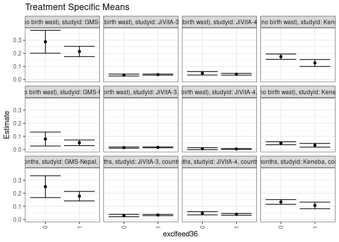

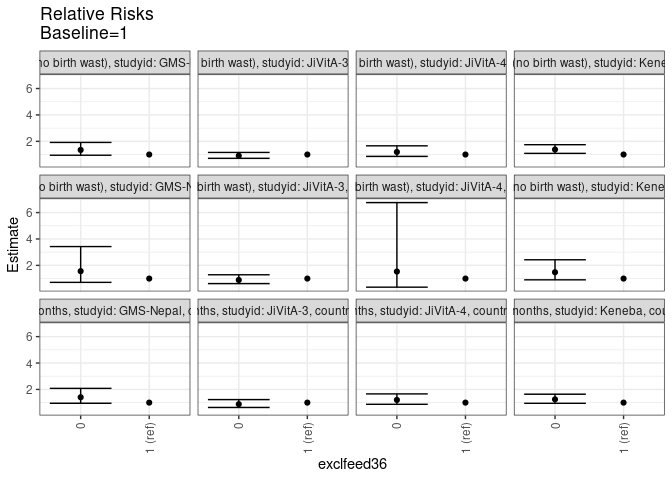

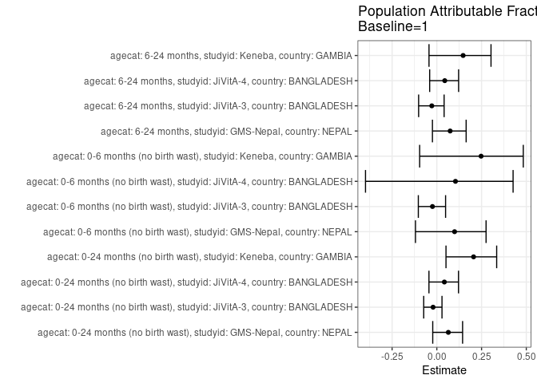

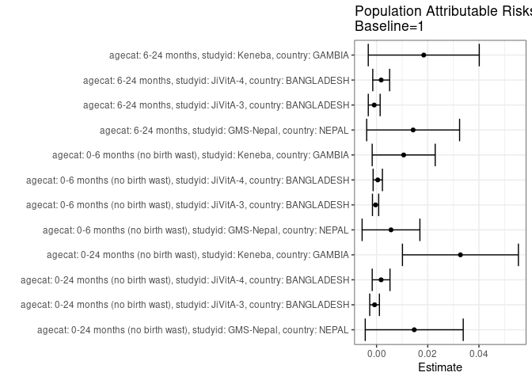

## Results Table

### Parameter: TSM

| agecat | studyid | country | intervention_level | baseline_level | estimate | ci_lower | ci_upper |
| --- | --- | --- | --- | --- | --- | --- | --- |
| 0-24 months (no birth wast) | GMS-Nepal | NEPAL | 1 | NA | 0.2142857 | 0.1750061 | 0.2535653 |
| 0-24 months (no birth wast) | GMS-Nepal | NEPAL | 0 | NA | 0.2884615 | 0.2013071 | 0.3756159 |
| 0-24 months (no birth wast) | JiVitA-3 | BANGLADESH | 1 | NA | 0.0378555 | 0.0334907 | 0.0422204 |
| 0-24 months (no birth wast) | JiVitA-3 | BANGLADESH | 0 | NA | 0.0343593 | 0.0269947 | 0.0417240 |
| 0-24 months (no birth wast) | JiVitA-4 | BANGLADESH | 1 | NA | 0.0403409 | 0.0334364 | 0.0472454 |
| 0-24 months (no birth wast) | JiVitA-4 | BANGLADESH | 0 | NA | 0.0481232 | 0.0347538 | 0.0614925 |
| 0-24 months (no birth wast) | Keneba | GAMBIA | 1 | NA | 0.1268058 | 0.1006698 | 0.1529418 |
| 0-24 months (no birth wast) | Keneba | GAMBIA | 0 | NA | 0.1746854 | 0.1544334 | 0.1949374 |
| 0-6 months (no birth wast) | GMS-Nepal | NEPAL | 1 | NA | 0.0512195 | 0.0298604 | 0.0725786 |
| 0-6 months (no birth wast) | GMS-Nepal | NEPAL | 0 | NA | 0.0800000 | 0.0267753 | 0.1332247 |
| 0-6 months (no birth wast) | JiVitA-3 | BANGLADESH | 1 | NA | 0.0161989 | 0.0131056 | 0.0192923 |
| 0-6 months (no birth wast) | JiVitA-3 | BANGLADESH | 0 | NA | 0.0144613 | 0.0099459 | 0.0189767 |
| 0-6 months (no birth wast) | JiVitA-4 | BANGLADESH | 1 | NA | 0.0040416 | 0.0006666 | 0.0074166 |
| 0-6 months (no birth wast) | JiVitA-4 | BANGLADESH | 0 | NA | 0.0061920 | -0.0013383 | 0.0137222 |
| 0-6 months (no birth wast) | Keneba | GAMBIA | 1 | NA | 0.0322581 | 0.0183469 | 0.0461692 |
| 0-6 months (no birth wast) | Keneba | GAMBIA | 0 | NA | 0.0477612 | 0.0363399 | 0.0591825 |
| 6-24 months | GMS-Nepal | NEPAL | 1 | NA | 0.1777251 | 0.1412171 | 0.2142331 |
| 6-24 months | GMS-Nepal | NEPAL | 0 | NA | 0.2500000 | 0.1666999 | 0.3333001 |
| 6-24 months | JiVitA-3 | BANGLADESH | 1 | NA | 0.0335689 | 0.0287084 | 0.0384294 |
| 6-24 months | JiVitA-3 | BANGLADESH | 0 | NA | 0.0295858 | 0.0205970 | 0.0385746 |
| 6-24 months | JiVitA-4 | BANGLADESH | 1 | NA | 0.0390382 | 0.0323898 | 0.0456866 |
| 6-24 months | JiVitA-4 | BANGLADESH | 0 | NA | 0.0469799 | 0.0343377 | 0.0596220 |
| 6-24 months | Keneba | GAMBIA | 1 | NA | 0.1070812 | 0.0818879 | 0.1322745 |
| 6-24 months | Keneba | GAMBIA | 0 | NA | 0.1335849 | 0.1152619 | 0.1519079 |

### Parameter: E(Y)

| agecat | studyid | country | intervention_level | baseline_level | estimate | ci_lower | ci_upper |
| --- | --- | --- | --- | --- | --- | --- | --- |
| 0-24 months (no birth wast) | GMS-Nepal | NEPAL | NA | NA | 0.2290076 | 0.1929956 | 0.2650196 |
| 0-24 months (no birth wast) | JiVitA-3 | BANGLADESH | NA | NA | 0.0370783 | 0.0333023 | 0.0408543 |
| 0-24 months (no birth wast) | JiVitA-4 | BANGLADESH | NA | NA | 0.0421145 | 0.0360504 | 0.0481786 |
| 0-24 months (no birth wast) | Keneba | GAMBIA | NA | NA | 0.1595745 | 0.1434154 | 0.1757335 |
| 0-6 months (no birth wast) | GMS-Nepal | NEPAL | NA | NA | 0.0568627 | 0.0367445 | 0.0769810 |
| 0-6 months (no birth wast) | JiVitA-3 | BANGLADESH | NA | NA | 0.0158131 | 0.0132056 | 0.0184207 |
| 0-6 months (no birth wast) | JiVitA-4 | BANGLADESH | NA | NA | 0.0045116 | 0.0014181 | 0.0076051 |
| 0-6 months (no birth wast) | Keneba | GAMBIA | NA | NA | 0.0428571 | 0.0338884 | 0.0518259 |
| 6-24 months | GMS-Nepal | NEPAL | NA | NA | 0.1920152 | 0.1583224 | 0.2257081 |
| 6-24 months | JiVitA-3 | BANGLADESH | NA | NA | 0.0326531 | 0.0283158 | 0.0369903 |
| 6-24 months | JiVitA-4 | BANGLADESH | NA | NA | 0.0408475 | 0.0350297 | 0.0466653 |
| 6-24 months | Keneba | GAMBIA | NA | NA | 0.1255252 | 0.1106396 | 0.1404109 |

### Parameter: RR

| agecat | studyid | country | intervention_level | baseline_level | estimate | ci_lower | ci_upper |
| --- | --- | --- | --- | --- | --- | --- | --- |
| 0-24 months (no birth wast) | GMS-Nepal | NEPAL | 1 | 1 | 1.0000000 | 1.0000000 | 1.000000 |
| 0-24 months (no birth wast) | GMS-Nepal | NEPAL | 0 | 1 | 1.3461538 | 0.9454057 | 1.916775 |
| 0-24 months (no birth wast) | JiVitA-3 | BANGLADESH | 1 | 1 | 1.0000000 | 1.0000000 | 1.000000 |
| 0-24 months (no birth wast) | JiVitA-3 | BANGLADESH | 0 | 1 | 0.9076438 | 0.7118755 | 1.157249 |
| 0-24 months (no birth wast) | JiVitA-4 | BANGLADESH | 1 | 1 | 1.0000000 | 1.0000000 | 1.000000 |
| 0-24 months (no birth wast) | JiVitA-4 | BANGLADESH | 0 | 1 | 1.1929130 | 0.8574144 | 1.659689 |
| 0-24 months (no birth wast) | Keneba | GAMBIA | 1 | 1 | 1.0000000 | 1.0000000 | 1.000000 |
| 0-24 months (no birth wast) | Keneba | GAMBIA | 0 | 1 | 1.3775825 | 1.0874671 | 1.745095 |
| 0-6 months (no birth wast) | GMS-Nepal | NEPAL | 1 | 1 | 1.0000000 | 1.0000000 | 1.000000 |
| 0-6 months (no birth wast) | GMS-Nepal | NEPAL | 0 | 1 | 1.5619048 | 0.7122754 | 3.425005 |
| 0-6 months (no birth wast) | JiVitA-3 | BANGLADESH | 1 | 1 | 1.0000000 | 1.0000000 | 1.000000 |
| 0-6 months (no birth wast) | JiVitA-3 | BANGLADESH | 0 | 1 | 0.8927330 | 0.6192260 | 1.287046 |
| 0-6 months (no birth wast) | JiVitA-4 | BANGLADESH | 1 | 1 | 1.0000000 | 1.0000000 | 1.000000 |
| 0-6 months (no birth wast) | JiVitA-4 | BANGLADESH | 0 | 1 | 1.5320654 | 0.3473637 | 6.757254 |
| 0-6 months (no birth wast) | Keneba | GAMBIA | 1 | 1 | 1.0000000 | 1.0000000 | 1.000000 |
| 0-6 months (no birth wast) | Keneba | GAMBIA | 0 | 1 | 1.4805970 | 0.9042366 | 2.424330 |
| 6-24 months | GMS-Nepal | NEPAL | 1 | 1 | 1.0000000 | 1.0000000 | 1.000000 |
| 6-24 months | GMS-Nepal | NEPAL | 0 | 1 | 1.4066667 | 0.9510304 | 2.080597 |
| 6-24 months | JiVitA-3 | BANGLADESH | 1 | 1 | 1.0000000 | 1.0000000 | 1.000000 |
| 6-24 months | JiVitA-3 | BANGLADESH | 0 | 1 | 0.8813454 | 0.6321884 | 1.228700 |
| 6-24 months | JiVitA-4 | BANGLADESH | 1 | 1 | 1.0000000 | 1.0000000 | 1.000000 |
| 6-24 months | JiVitA-4 | BANGLADESH | 0 | 1 | 1.2034335 | 0.8720674 | 1.660711 |
| 6-24 months | Keneba | GAMBIA | 1 | 1 | 1.0000000 | 1.0000000 | 1.000000 |
| 6-24 months | Keneba | GAMBIA | 0 | 1 | 1.2475107 | 0.9501014 | 1.638018 |

### Parameter: PAR

| agecat | studyid | country | intervention_level | baseline_level | estimate | ci_lower | ci_upper |
| --- | --- | --- | --- | --- | --- | --- | --- |
| 0-24 months (no birth wast) | GMS-Nepal | NEPAL | 1 | NA | 0.0147219 | -0.0044202 | 0.0338640 |
| 0-24 months (no birth wast) | JiVitA-3 | BANGLADESH | 1 | NA | -0.0007772 | -0.0026759 | 0.0011214 |
| 0-24 months (no birth wast) | JiVitA-4 | BANGLADESH | 1 | NA | 0.0017736 | -0.0016982 | 0.0052454 |
| 0-24 months (no birth wast) | Keneba | GAMBIA | 1 | NA | 0.0327687 | 0.0101184 | 0.0554190 |
| 0-6 months (no birth wast) | GMS-Nepal | NEPAL | 1 | NA | 0.0056432 | -0.0056457 | 0.0169322 |
| 0-6 months (no birth wast) | JiVitA-3 | BANGLADESH | 1 | NA | -0.0003858 | -0.0016002 | 0.0008286 |
| 0-6 months (no birth wast) | JiVitA-4 | BANGLADESH | 1 | NA | 0.0004700 | -0.0013438 | 0.0022839 |
| 0-6 months (no birth wast) | Keneba | GAMBIA | 1 | NA | 0.0105991 | -0.0017105 | 0.0229087 |
| 6-24 months | GMS-Nepal | NEPAL | 1 | NA | 0.0142901 | -0.0038600 | 0.0324402 |
| 6-24 months | JiVitA-3 | BANGLADESH | 1 | NA | -0.0009158 | -0.0032325 | 0.0014008 |
| 6-24 months | JiVitA-4 | BANGLADESH | 1 | NA | 0.0018093 | -0.0014843 | 0.0051030 |
| 6-24 months | Keneba | GAMBIA | 1 | NA | 0.0184440 | -0.0032415 | 0.0401296 |

### Parameter: PAF

| agecat | studyid | country | intervention_level | baseline_level | estimate | ci_lower | ci_upper |
| --- | --- | --- | --- | --- | --- | --- | --- |
| 0-24 months (no birth wast) | GMS-Nepal | NEPAL | 1 | NA | 0.0642857 | -0.0228513 | 0.1439995 |
| 0-24 months (no birth wast) | JiVitA-3 | BANGLADESH | 1 | NA | -0.0209622 | -0.0733362 | 0.0288562 |
| 0-24 months (no birth wast) | JiVitA-4 | BANGLADESH | 1 | NA | 0.0421135 | -0.0440373 | 0.1211554 |
| 0-24 months (no birth wast) | Keneba | GAMBIA | 1 | NA | 0.2053505 | 0.0512176 | 0.3344439 |
| 0-6 months (no birth wast) | GMS-Nepal | NEPAL | 1 | NA | 0.0992431 | -0.1193952 | 0.2751773 |
| 0-6 months (no birth wast) | JiVitA-3 | BANGLADESH | 1 | NA | -0.0243971 | -0.1033710 | 0.0489242 |
| 0-6 months (no birth wast) | JiVitA-4 | BANGLADESH | 1 | NA | 0.1041859 | -0.3985239 | 0.4261929 |
| 0-6 months (no birth wast) | Keneba | GAMBIA | 1 | NA | 0.2473118 | -0.0960055 | 0.4830870 |
| 6-24 months | GMS-Nepal | NEPAL | 1 | NA | 0.0744217 | -0.0245371 | 0.1638221 |
| 6-24 months | JiVitA-3 | BANGLADESH | 1 | NA | -0.0280477 | -0.1017159 | 0.0406946 |
| 6-24 months | JiVitA-4 | BANGLADESH | 1 | NA | 0.0442950 | -0.0400166 | 0.1217717 |
| 6-24 months | Keneba | GAMBIA | 1 | NA | 0.1469349 | -0.0437463 | 0.3027807 |